# final

Melee: Impact of the Slippi Era  
Vicki Wong

Super Smash Bros. Melee is a fighting game released on the Nintendo GameCube in 2001. The game has maintained an active competitive community to this day, enough to comprise a history of tournament sets spanning several years. However, its age meant that compared to modern titles, it was more cumbersome to organize and play practice matches, especially online. In the midst of the pandemic, the summer of 2020, a project called Slippi updated, which modded the game to offer online matchmaking built in, rollback netcode to handle delay from online play, and detailed replay data for analysis. This allowed players to reliably and easily practice online at any time when playing in person wasn't possible due to corona, which had then put a complete halt to major tournaments. Paired with the availability of personal statistics, it is believed that Slippi granted players the perfect opportunity to endlessly grind and improve their skills, provided they were willing to put in the time. In this tutorial I will be looking at tournament results prior to and after Slippi to see if this had a significant impact on the rankings of the top players.

smashdata.gg is an open database that records tournament results, and I will be using their sqlite database to aid me in my analysis. Slippi came out with their major update adding rollback netcode on June 22, 2020, resulting in a mass influx of new users, so this day will be the divider for our data.

```python
import sqlite3
import pandas as pd

# dataset available at https://github.com/smashdata/ThePlayerDatabase
# download the .zip file for Melee, and unzip to get the .db file
file = 'melee_player_database.db'
con = sqlite3.connect(file)

# unix timestamp of June 22, 2020 is 1592798400
# unix timestamp of January 1, 2018 is 1514782800
before_query = 'SELECT * FROM tournament_info WHERE start < 1592798400'
before = pd.read_sql(before_query, con)
after_query = 'SELECT * FROM tournament_info WHERE start >= 1592798400'
after = pd.read_sql(after_query, con)
```

Next, we want to see who had consistent tournament placings by looking at the top 4 players from every tournament. For each player, the player id and placing are stored as a pair, and we'll look up the player id from another table at the end.

```python
import re

before_top = {}
# store the top 4
for i in before['placings']:
    # use regex to search the string
    try:
        one = re.findall(r"\"(\d+)\", [1|2|3|4]]", i)
        for match in one:
            if match in before_top:
                before_top[match] += 1
            else:
                before_top[match] = 1
    except:
        pass

after_top = {}
for i in after['placings']:
    try:
        one = re.findall(r"\"(\d+)\", [1|2|3|4]]", i)
        for match in one:
            if match in after_top:
                after_top[match] += 1
            else:
                after_top[match] = 1
    except:
        pass
```

```python
# looking up our player id
player_query = 'SELECT * FROM players WHERE player_id == 65777'
player = pd.read_sql(player_query, con)
player
```

|  | game | player_id | tag | all_tags | prefixes | social | country | state | region | c_country | c_state | c_region | placings | characters | alias |
| --- | --- | --- | --- | --- | --- | --- | --- | --- | --- | --- | --- | --- | --- | --- | --- |
| 0 | melee | 65777 | bobby big ballz | ["bobby big ballz"] | ["EMG"] | {"twitter": ["bobbybigballz19"]} | United States | TX | None | US | CA | Fountain Valley | [{"key": "slippi-champions-league-week-3__mele... | {"melee/falco": 8191, "melee/jigglypuff": 86, ... | None |

Instead, let's only compare the results from major tournaments, where it will be required to beat highly skilled players in order to place in the top 4. Additionally, since we want to see the difference before and after Slippi, the period for the time before will be from 2018-2020.

```python
# filtering based on list at https://liquipedia.net/smash/Major_Tournaments/Melee

# reduce period to 2018-2020
before_query = 'SELECT * FROM tournament_info WHERE start < 1592798400 AND start >= 1514782800'
before = pd.read_sql(before_query, con)

after_top = {}
for i, j in zip(after['placings'], after['cleaned_name']):
    after_tourney = re.findall(r'Line|Ludwig|MIXUP|Slippi Champions League|Smash Summit|Valhalla|Upset|Loko|Galint|Riptide|SWT 2021|SAME\
        |Mainstage|GENESIS|Pound|Double Down', j)
    # check if the tournament is a major and only process if it is
    if not after_tourney:
        pass
    else:
        try:
            one = re.findall(r"\"(\d+)\", [1|2|3|4]]", i)
            for match in one:
                if match in after_top:
                    after_top[match] += 1
                else:
                    after_top[match] = 1
        except:
            pass

before_top = {}
for i, j in zip(before['placings'], before['cleaned_name']):
    before_tourney = re.findall(r'Smash Summit|GENESIS|Mango\'s|Big House|Mainstage|Shine|Super Smash Con|Low|CEO|Splash|Level|Pound|GameTyrant\
        |Heir|EVO|Flatiron|Bloom|Enthusiast', j)
    if not before_tourney:
        pass
    else:
        try:
            one = re.findall(r"\"(\d+)\", [1|2|3|4]]", i)
            for match in one:
                if match in before_top:
                    before_top[match] += 1
                else:
                    before_top[match] = 1
        except:
            pass

before_top
```

```
{'1004': 23,
 '1000': 10,
 '15990': 9,
 '6126': 11,
 '19573': 1,
 '1008': 1,
 '4465': 13,
 '1017': 3,
 '6189': 6,
 '1012': 2,
 '1003': 5,
 '23458': 1,
 '1028': 7,
 '16342': 6,
 '4401': 1,
 '1021': 2,
 '1019': 3,
 '3560': 1,
 '19554': 3,
 '15634': 1,
 '15179': 1,
 '1016': 1,
 '4107': 2,
 '1007': 1,
 '3665': 1,
 '26153': 1,
 '18840': 1,
 '14282': 1,
 '143153': 2,
 '318568': 2,
 '694497': 2,
 '14593': 1,
 '7731': 1,
 '1077': 1,
 '1009': 1}
```

From 2018-2020, the player with the most top 4 placements is Hungrybox, with a total of 23. Next are Leffen with 13, Zain with 11, and Mang0 with 10.

```python
before_players = pd.DataFrame()

player_query = 'SELECT * FROM players WHERE player_id == 1004'
player = pd.read_sql(player_query, con)
before_players = before_players.append(player)

player_query = 'SELECT * FROM players WHERE player_id == 4465'
player = pd.read_sql(player_query, con)
before_players = before_players.append(player)

player_query = 'SELECT * FROM players WHERE player_id == 6126'
player = pd.read_sql(player_query, con)
before_players = before_players.append(player)

player_query = 'SELECT * FROM players WHERE player_id == 1000'
player = pd.read_sql(player_query, con)
before_players = before_players.append(player)

before_players
```

|  | game | player_id | tag | all_tags | prefixes | social | country | state | region | c_country | c_state | c_region | placings | characters | alias |
| --- | --- | --- | --- | --- | --- | --- | --- | --- | --- | --- | --- | --- | --- | --- | --- |
| 0 | melee | 1004 | Hungrybox | ["Juanthefatty", "Liquid`Hungrybox", "Liquid` ... | ["Liquid"] | {"twitter": ["LiquidHbox"]} | United States | FL | None | US | CA | Fountain Valley | [{"key": "slippi-champions-league-week-1__mele... | {"melee/jigglypuff": 3043, "melee/ness": 8, "m... | None |
| 0 | melee | 4465 | Leffen | ["TSM \| Leffen", "Leffen", "TSM\|Leffen", "TSM ... | ["TSM"] | {"twitter": ["tsm_leffen", "TSM_Leffen"]} | Sweden |  |  | US | CA | Los Angeles | [{"key": "httpsparagonchallongecomla_2015_mele... | {"melee/fox": 906, "melee/marth": 4, "melee/do... | None |
| 0 | melee | 6126 | Zain | ["Zain", "DontTestMe"] | ["PG"] | {"twitter": ["PG_Zain"]} | United States | VA | None | US | CA |  | [{"key": "slippi-champions-league-week-1__mele... | {"melee/marth": 574, "melee/pichu": 1, "melee/... | DontTestMe |
| 0 | melee | 1000 | Mang0 | ["C9 \| Mango", "Mango", "C9. Mango", "C9\|Mango... | ["C9"] | {"twitter": ["C9Mang0"]} | United States | CA | SoCal | US | CA | Los Angeles | [{"key": "slippi-champions-league-week-1__mele... | {"melee/falco": 644, "melee/fox": 436, "melee/... | None |

```python
after_top
```

```
{'1000': 9,
 '6126': 11,
 '4107': 6,
 '19554': 11,
 '3359': 3,
 '3357': 2,
 '15990': 5,
 '1019': 6,
 '3561': 2,
 '1004': 8,
 '1028': 4,
 '29829': 1,
 '1036': 1,
 '4648': 1,
 '3954': 1,
 '22900': 2,
 '5563': 1,
 '4465': 3,
 '261464': 2,
 '16342': 1,
 '1007': 1,
 '282096': 3,
 '11139': 3,
 '686245': 1,
 '21553': 2,
 '1017': 2,
 '1039': 1,
 '5080': 4,
 '3299': 1,
 '1084': 1,
 '53365': 1,
 '51240': 2,
 '61873': 1,
 '132938': 1,
 '32650': 1,
 '585236': 2,
 '1164314': 1,
 '223213': 1,
 '452271': 1,
 '1847536': 1,
```

[output cut: 23 more lines]

```
 '35318': 1,
 '35720': 1,
 '2744323': 1,
 '139305': 1,
 '10591': 1,
 '4692': 1,
 '32243': 1,
 '68163': 1,
 '1114034': 1,
 '1050049': 1,
 '1021': 1,
 '15634': 1,
 '325974': 1,
 '21772': 1,
 '51373': 1}
```

From 2020-2022, the players with the most top 4 placements are Zain and iBDW, both with a total of 11. Next are Mang0 with 9 and Hungrybox with 8. Compared to Hungrybox's relative dominance in the previous period with 10 placements over Leffen, now the competition is a lot more evenly balanced. The range within the top 4 in 2018-2020 was 23 - 10 = 13 and has been flattened in 2020-2022 to 11 - 8 = 3. iBDW had the most drastic change, only managing 3 placements in 2018-2020, far behind the rest of the crowd, and shooting up to tie for first in 2020-2022. Zain, iBDW, and Mang0 are players known to practice a lot with Slippi, while Hungrybox has had to focus on other priorities.

```python
after_players = pd.DataFrame()

player_query = 'SELECT * FROM players WHERE player_id == 6126'
player = pd.read_sql(player_query, con)
after_players = after_players.append(player)

player_query = 'SELECT * FROM players WHERE player_id == 19554'
player = pd.read_sql(player_query, con)
after_players = after_players.append(player)

player_query = 'SELECT * FROM players WHERE player_id == 1000'
player = pd.read_sql(player_query, con)
after_players = after_players.append(player)

player_query = 'SELECT * FROM players WHERE player_id == 1004'
player = pd.read_sql(player_query, con)
after_players = after_players.append(player)

after_players
```

|  | game | player_id | tag | all_tags | prefixes | social | country | state | region | c_country | c_state | c_region | placings | characters | alias |
| --- | --- | --- | --- | --- | --- | --- | --- | --- | --- | --- | --- | --- | --- | --- | --- |
| 0 | melee | 6126 | Zain | ["Zain", "DontTestMe"] | ["PG"] | {"twitter": ["PG_Zain"]} | United States | VA | None | US | CA |  | [{"key": "slippi-champions-league-week-1__mele... | {"melee/marth": 574, "melee/pichu": 1, "melee/... | DontTestMe |
| 0 | melee | 19554 | iBDW | ["iBDW"] | ["Panda", "MnT", "Ace", "PG"] | {"twitter": ["SSBMiBDW", "iBDWSSBM"]} | United States | NY | None | US | CA |  | [{"key": "slippi-champions-league-week-1__mele... | {"melee/fox": 951, "melee/sheik": 57, "melee/f... | None |
| 0 | melee | 1000 | Mang0 | ["C9 \| Mango", "Mango", "C9. Mango", "C9\|Mango... | ["C9"] | {"twitter": ["C9Mang0"]} | United States | CA | SoCal | US | CA | Los Angeles | [{"key": "slippi-champions-league-week-1__mele... | {"melee/falco": 644, "melee/fox": 436, "melee/... | None |
| 0 | melee | 1004 | Hungrybox | ["Juanthefatty", "Liquid`Hungrybox", "Liquid` ... | ["Liquid"] | {"twitter": ["LiquidHbox"]} | United States | FL | None | US | CA | Fountain Valley | [{"key": "slippi-champions-league-week-1__mele... | {"melee/jigglypuff": 3043, "melee/ness": 8, "m... | None |

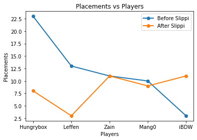

```python
import matplotlib.pyplot as plt

# making table for graph
dict = {'name': ['Hungrybox', 'Leffen', 'Zain', 'Mang0', 'iBDW'],
        'before': [23, 13, 11, 10, 3],
        'after': [8, 3, 11, 9, 11]}
change = pd.DataFrame(dict)

# create graph
fig, ax = plt.subplots()
ax.set_xlabel('Players')
ax.set_ylabel('Placements')
ax.set_title('Placements vs Players')
ax.plot(change['name'], change['before'], marker='o', linewidth=2, label='Before Slippi')
ax.plot(change['name'], change['after'], marker='o', linewidth=2, label='After Slippi')
plt.legend()
```

```python
# separate data into 2019 and 2021
nineteen_query = 'SELECT * FROM tournament_info WHERE start >= 1546318800 AND start < 1577854800'
before = pd.read_sql(nineteen_query, con)
twentyone_query = 'SELECT * FROM tournament_info WHERE start >= 1609477200 AND start < 1641013200'
after = pd.read_sql(twentyone_query, con)

# 2021
after_top = {}
for i, j in zip(after['placings'], after['cleaned_name']):
    after_tourney = re.findall(r'Line|Ludwig|MIXUP|Slippi Champions League|Smash Summit|Valhalla|Upset|Loko|Galint|Riptide|SWT 2021|SAME\
        |Mainstage|GENESIS|Pound|Double Down', j)
    if not after_tourney:
        pass
    else:
        try:
            # add different amounts to score based on placement
            one = re.findall(r"\"(\d+)\", 1]", i)
            for match in one:
                if match in after_top:
                    after_top[match] += 1.0
                else:
                    after_top[match] = 1.0
            two = re.findall(r"\"(\d+)\", 2]", i)
            for match in one:
                if match in after_top:
                    after_top[match] += 0.9
                else:
                    after_top[match] = 0.9
            three = re.findall(r"\"(\d+)\", 3]", i)
            for match in one:
                if match in after_top:
                    after_top[match] += 0.5
                else:
                    after_top[match] = 0.5
            four = re.findall(r"\"(\d+)\", 4]", i)
            for match in one:
                if match in after_top:
                    after_top[match] += 0.3
                else:
                    after_top[match] = 0.3
        except:
            pass

# 2019
before_top = {}
for i, j in zip(before['placings'], before['cleaned_name']):
    before_tourney = re.findall(r'Smash Summit|GENESIS|Mango\'s|Big House|Mainstage|Shine|Super Smash Con|Low|CEO|Splash|Level|Pound|GameTyrant\
        |Heir|EVO|Flatiron|Bloom|Enthusiast', j)
    if not before_tourney:
        pass
    else:
        try:
            one = re.findall(r"\"(\d+)\", 1]", i)
            for match in one:
                if match in before_top:
                    before_top[match] += 1.0
                else:
                    before_top[match] = 1.0
            two = re.findall(r"\"(\d+)\", 2]", i)
            for match in one:
                if match in before_top:
                    before_top[match] += 0.9
                else:
                    before_top[match] = 0.9
            three = re.findall(r"\"(\d+)\", 3]", i)
            for match in one:
                if match in before_top:
                    before_top[match] += 0.5
                else:
                    before_top[match] = 0.5
            four = re.findall(r"\"(\d+)\", 4]", i)
            for match in one:
                if match in before_top:
                    before_top[match] += 0.3
                else:
                    before_top[match] = 0.3
        except:
            pass

before_top
```

```
{'1000': 8.1,
 '1004': 16.200000000000003,
 '6126': 2.6999999999999997,
 '1028': 2.6999999999999997,
 '16342': 2.6999999999999997,
 '4465': 2.6999999999999997}
```

We're going to place weights depending on how high a player placed to calculate our values for ranking.

```python
before_players = pd.DataFrame()

player_query = 'SELECT * FROM players WHERE player_id == 1004'
player = pd.read_sql(player_query, con)
before_players = before_players.append(player)

player_query = 'SELECT * FROM players WHERE player_id == 1000'
player = pd.read_sql(player_query, con)
before_players = before_players.append(player)

player_query = 'SELECT * FROM players WHERE player_id == 6126'
player = pd.read_sql(player_query, con)
before_players = before_players.append(player)

player_query = 'SELECT * FROM players WHERE player_id == 1028'
player = pd.read_sql(player_query, con)
before_players = before_players.append(player)

player_query = 'SELECT * FROM players WHERE player_id == 16342'
player = pd.read_sql(player_query, con)
before_players = before_players.append(player)

player_query = 'SELECT * FROM players WHERE player_id == 4465'
player = pd.read_sql(player_query, con)
before_players = before_players.append(player)

before_players
```

|  | game | player_id | tag | all_tags | prefixes | social | country | state | region | c_country | c_state | c_region | placings | characters | alias |
| --- | --- | --- | --- | --- | --- | --- | --- | --- | --- | --- | --- | --- | --- | --- | --- |
| 0 | melee | 1004 | Hungrybox | ["Juanthefatty", "Liquid`Hungrybox", "Liquid` ... | ["Liquid"] | {"twitter": ["LiquidHbox"]} | United States | FL | None | US | CA | Fountain Valley | [{"key": "slippi-champions-league-week-1__mele... | {"melee/jigglypuff": 3043, "melee/ness": 8, "m... | None |
| 0 | melee | 1000 | Mang0 | ["C9 \| Mango", "Mango", "C9. Mango", "C9\|Mango... | ["C9"] | {"twitter": ["C9Mang0"]} | United States | CA | SoCal | US | CA | Los Angeles | [{"key": "slippi-champions-league-week-1__mele... | {"melee/falco": 644, "melee/fox": 436, "melee/... | None |
| 0 | melee | 6126 | Zain | ["Zain", "DontTestMe"] | ["PG"] | {"twitter": ["PG_Zain"]} | United States | VA | None | US | CA |  | [{"key": "slippi-champions-league-week-1__mele... | {"melee/marth": 574, "melee/pichu": 1, "melee/... | DontTestMe |
| 0 | melee | 1028 | Wizzrobe | ["Wizzzrobe", "COG \| Wizzrobe", "COG Wizzrobe"... | ["Envy", "ExG"] | {"twitter": ["Wizzrobe"]} | United States | FL | None | US | CA |  | [{"key": "slippi-champions-league-week-1__mele... | {"melee/captainfalcon": 708} | None |
| 0 | melee | 16342 | Axe | ["Axe09", "Tempo \| Axe", "MOR \| Axe", "Axe", "... | ["Tempo"] | {"twitter": ["TempoAxe"]} | United States | AZ | None | US | CA | Los Angeles | [{"key": "slippi-champions-league-week-1__mele... | {"melee/pikachu": 761, "melee/falco": 64, "mel... | None |
| 0 | melee | 4465 | Leffen | ["TSM \| Leffen", "Leffen", "TSM\|Leffen", "TSM ... | ["TSM"] | {"twitter": ["tsm_leffen", "TSM_Leffen"]} | Sweden |  |  | US | CA | Los Angeles | [{"key": "httpsparagonchallongecomla_2015_mele... | {"melee/fox": 906, "melee/marth": 4, "melee/do... | None |

Our way of quantifying placements leaves us with a lot of ties, since if a player gets first place the others will have to grab the lower placements and so on. Then to fix this we can use 2018's results as a base and assign base values to each player.

```python
# 2018 rankings
# Hungrybox - 1
# Mang0 - 5
# Zain - 7
# Wizzrobe - 8
# Axe - 10
# Leffen - 3

# base value added will be:
# Hungrybox - 10
# Mang0 - 6
# Zain - 5
# Wizzrobe - 4
# Axe - 2
# Leffen - 9

to_add = [10, 6, 5, 4, 2, 9]
count = 0
for i in before_top:
    before_top[i] += to_add[count]
    count += 1

before_top
```

[output not shown]

Now our ranking becomes Hungrybox, Mang0, Leffen, Zain, Wizzrobe, and Axe. The actual 2019 ranking is Hungrybox, Leffen, Mang0, Axe, Wizzrobe, and Zain, so we managed to get the right people in the top 6 and the max error was +- 2 places. Even though the actual ranking takes player and community opinion into account, it seems that showing results is a core component to the rankings.

```python
after_top
```

```
{'1004': 8.1,
 '261464': 2.6999999999999997,
 '4465': 2.6999999999999997,
 '6126': 2.6999999999999997,
 '1017': 2.6999999999999997,
 '53365': 2.6999999999999997,
 '1000': 2.6999999999999997,
 '585236': 2.6999999999999997,
 '223213': 2.6999999999999997,
 '1019': 2.6999999999999997,
 '19554': 5.3999999999999995,
 '1028': 2.6999999999999997,
 '21553': 2.6999999999999997,
 '6544': 2.6999999999999997,
 '3357': 2.6999999999999997}
```

```python
after_players = pd.DataFrame()

player_query = 'SELECT * FROM players WHERE player_id == 261464'
player = pd.read_sql(player_query, con)
after_players = after_players.append(player)

player_query = 'SELECT * FROM players WHERE player_id == 1017'
player = pd.read_sql(player_query, con)
after_players = after_players.append(player)

player_query = 'SELECT * FROM players WHERE player_id == 53365'
player = pd.read_sql(player_query, con)
after_players = after_players.append(player)

player_query = 'SELECT * FROM players WHERE player_id == 585236'
player = pd.read_sql(player_query, con)
after_players = after_players.append(player)

player_query = 'SELECT * FROM players WHERE player_id == 223213'
player = pd.read_sql(player_query, con)
after_players = after_players.append(player)

player_query = 'SELECT * FROM players WHERE player_id == 1019'
player = pd.read_sql(player_query, con)
after_players = after_players.append(player)

player_query = 'SELECT * FROM players WHERE player_id == 19554'
player = pd.read_sql(player_query, con)
after_players = after_players.append(player)

player_query = 'SELECT * FROM players WHERE player_id == 21553'
player = pd.read_sql(player_query, con)
after_players = after_players.append(player)

player_query = 'SELECT * FROM players WHERE player_id == 6544'
player = pd.read_sql(player_query, con)
after_players = after_players.append(player)

player_query = 'SELECT * FROM players WHERE player_id == 3357'
player = pd.read_sql(player_query, con)
after_players = after_players.append(player)

after_players
```

|  | game | player_id | tag | all_tags | prefixes | social | country | state | region | c_country | c_state | c_region | placings | characters | alias |
| --- | --- | --- | --- | --- | --- | --- | --- | --- | --- | --- | --- | --- | --- | --- | --- |
| 0 | melee | 261464 | Pipsqueak | ["Pipsqueak"] | ["DC", "FANA", "PS", "Melee Stats"] | {"twitter": ["DC_Pipsqueak"]} | Sweden | None | None | US | CA | Stockholm | [{"key": "heir-5__melee-singles", "placing": 3... | {"melee/fox": 598, "melee/marth": 4, "melee/sh... | None |
| 0 | melee | 1017 | S2J | ["S2j", "S2J", "s2j"] | ["Tempo", "bc", "HLCG", "HLC"] | {"twitter": ["Tempo_S2J", "johnny_S2J"]} | United States | CA | SoCal | US | CA | Fountain Valley | [{"key": "slippi-champions-league-week-1__mele... | {"melee/captainfalcon": 1607, "melee/falco": 9... | None |
| 0 | melee | 53365 | Ringler | ["Ringler"] | [] | {"twitter": ["Ringler_SSBM"]} | United States | CA | SoCal | US | CA | Burbank | [{"key": "evo-2016", "placing": 193, "seed": n... | {"melee/donkeykong": 262} | None |
| 0 | melee | 585236 | Amrak | ["Amrak"] | ["306", "Galint \| 306"] | {"twitter": []} | Canada | BC | None | CA | BC | Vancouver | [{"key": "don-t-park-on-the-grass-2018-1__mele... | {"melee/fox": 608} | None |
| 0 | melee | 223213 | Sock | ["Sock"] | ["ATH", "GZ", "OVERT", "MF"] | {"twitter": ["SockSSBM"]} | Australia | NSW | None | US | CA | Fountain Valley | [{"key": "nimbus-69__melee-singles", "placing"... | {"melee/fox": 382, "melee/marth": 32, "melee/s... | None |
| 0 | melee | 1019 | SFAT | ["SFAT", "MIOM \| SFAT", "MIOM\|SFAT", "MIOM SFA... | ["CLG.", "CLG"] | {"twitter": ["SFAT"]} | United States | CA | NorCal | US | CA | Fountain Valley | [{"key": "slippi-champions-league-week-1__mele... | {"melee/fox": 1699, "melee/falco": 41, "melee/... | None |
| 0 | melee | 19554 | iBDW | ["iBDW"] | ["Panda", "MnT", "Ace", "PG"] | {"twitter": ["SSBMiBDW", "iBDWSSBM"]} | United States | NY | None | US | CA |  | [{"key": "slippi-champions-league-week-1__mele... | {"melee/fox": 951, "melee/sheik": 57, "melee/f... | None |
| 0 | melee | 21553 | Nicki | ["Nicki"] | ["CGN", "PS"] | {"twitter": ["leffenfanboy"]} | Germany | None | None | DE | Berlin | Berlin | [{"key": "heir-5__melee-singles", "placing": 7... | {"melee/fox": 320, "melee/iceclimbers": 16, "m... | None |
| 0 | melee | 6544 | Magi | ["Magi"] | ["bc"] | {"twitter": ["SSBMagi", "STSMagi"]} | United States | LA | None | US | CA | Oakland | [{"key": "slippi-champions-league-week-4__mele... | {"melee/falco": 539} | None |
| 0 | melee | 3357 | Spark | ["Spark"] | ["IluZ", "ULT", "TA"] | {"twitter": ["Spark_SSBM", "SSBM_Spark"]} | United States | CA | NorCal | US | CA | Oakland | [{"key": "slippi-champions-league-week-1__mele... | {"melee/sheik": 429, "melee/marth": 3, "melee/... | None |

```python
# 2019 rankings
# Hungrybox - 1
# Pipsqueak - 0
# Leffen - 2
# Zain - 6
# S2J - 11
# Ringler - 0
# Mang0 - 3
# Amrak - 0
# Sock - 0
# SFAT - 13
# iBDW - 9
# Wizzrobe - 5
# Nicki - 83
# Magi - 43
# Spark - 22

# base value added will be:
# Hungrybox - 20
# Pipsqueak - 0
# Leffen - 19
# Zain - 14
# S2J - 11
# Ringler - 0
# Mang0 - 17
# Amrak - 0
# Sock - 0
# SFAT - 10
# iBDW - 12
# Wizzrobe - 15
# Nicki - 1
# Magi - 3
# Spark - 6

to_add = [20, 0, 19, 14, 11, 0, 17, 0, 0, 10, 12, 15, 1, 3, 6]
count = 0
for i in after_top:
    after_top[i] += to_add[count]
    count += 1

after_top
```

```
{'1004': 28.1,
 '261464': 2.6999999999999997,
 '4465': 21.7,
 '6126': 16.7,
 '1017': 13.7,
 '53365': 2.6999999999999997,
 '1000': 19.7,
 '585236': 2.6999999999999997,
 '223213': 2.6999999999999997,
 '1019': 12.7,
 '19554': 17.4,
 '1028': 17.7,
 '21553': 3.6999999999999997,
 '6544': 5.699999999999999,
 '3357': 8.7}
```

In conclusion, we can see that Slippi has allowed for big gains for those who were stuck behind the top dogs, and its impact has been noticable in tournament results.